# SalesPeople

Kenneth Manuel (160419041), Jehuda Rivaldo (160419133)

4/25/2021

```r
library("readxl")
library("corrplot")
library("ggplot2")
library("ggfortify")
```

# Data Preparation

```r
data <- read_excel('Salespeople-data.xlsx')
head(data)
```

```
## # A tibble: 6 x 7
##   Salegrow saleproft Newsale createst Mechtest absttest mathtest
##      <dbl>     <dbl>   <dbl>    <dbl>    <dbl>    <dbl>    <dbl>
## 1     93        96      97.8        9       12        9       20
## 2     88.8      91.8    96.8        7       10       10       15
## 3     95       100.     99          8       12        9       26
## 4    101.      104.    107.        13       14       12       29
## 5    102       108.    103         10       15       12       32
## 6     95.8      97.5    99.3       10       14       11       21
```

```r
summary(data)
```

```
##     Salegrow        saleproft        Newsale          createst
##  Min.   : 81.50   Min.   : 87.3   Min.   : 94.30   Min.   : 1.00
##  1st Qu.: 94.42   1st Qu.: 99.5   1st Qu.: 99.08   1st Qu.: 8.25
##  Median :100.65   Median :106.2   Median :103.15   Median :10.00
##  Mean   : 98.96   Mean   :106.6   Mean   :102.81   Mean   :11.22
##  3rd Qu.:105.05   3rd Qu.:114.8   3rd Qu.:106.45   3rd Qu.:14.00
##  Max.   :110.80   Max.   :122.3   Max.   :115.30   Max.   :18.00
##     Mechtest        absttest        mathtest
##  Min.   : 5.00   Min.   : 5.00   Min.   : 9.00
##  1st Qu.:12.00   1st Qu.: 9.00   1st Qu.:21.50
##  Median :15.00   Median :11.00   Median :31.50
##  Mean   :14.18   Mean   :10.56   Mean   :29.76
##  3rd Qu.:17.00   3rd Qu.:12.00   3rd Qu.:37.00
##  Max.   :20.00   Max.   :15.00   Max.   :51.00
```

Gunakan variabel independen

```r
data_ip = data[4:7]
head(data_ip)
```

```
## # A tibble: 6 x 4
##   createst Mechtest absttest mathtest
##      <dbl>    <dbl>    <dbl>    <dbl>
## 1        9       12        9       20
## 2        7       10       10       15
## 3        8       12        9       26
## 4       13       14       12       29
## 5       10       15       12       32
## 6       10       14       11       21
```

Melihat *correlation plot* sepertinya semua variabel independen agak berkorelasi kecuali abstract test dan creative test.

```r
# Matrix correlation
data.cor = cor(data_ip[,])
data.cor
```

```
##           createst  Mechtest  absttest  mathtest
## createst 1.0000000 0.5907360 0.1469074 0.4126395
## Mechtest 0.5907360 1.0000000 0.3859502 0.5745533
## absttest 0.1469074 0.3859502 1.0000000 0.5663721
## mathtest 0.4126395 0.5745533 0.5663721 1.0000000
```

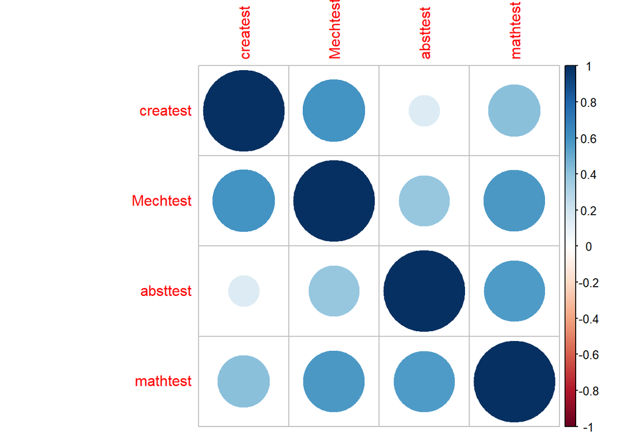

```r
corrplot(data.cor)
```

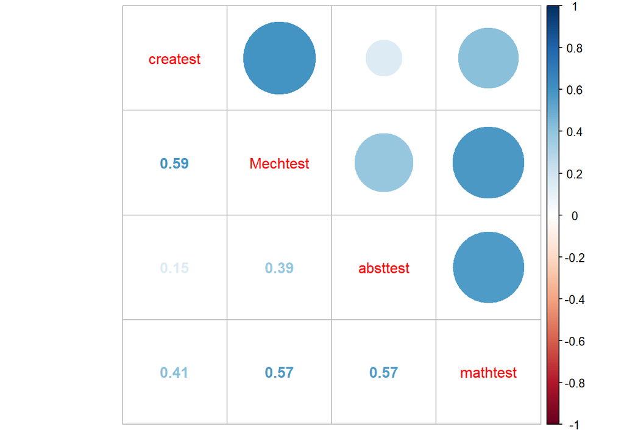

```r
corrplot.mixed(data.cor)
```

# Principal Component Analysis

Melihat visualisasi dan kesimpulan yang lebih ringkas dengan PCA

```r
fit <- prcomp(data_ip[,], scale=TRUE)
fit
```

```
## Standard deviations (1, .., p=4):
## [1] 1.5368630 0.9583733 0.6036777 0.5959413
##
## Rotation (n x k) = (4 x 4):
##                PC1        PC2        PC3        PC4
## createst 0.4526830  0.6434339 -0.2055992  0.5820652
## Mechtest 0.5514235  0.2466951 -0.1987056 -0.7717446
## absttest 0.4339023 -0.6850154 -0.5382775  0.2296521
## mathtest 0.5502173 -0.2364071  0.7927814  0.1134470
```

Dari masing-masing **Principal Component** dapat kita lihat bahwa 59% data dijelaskan dalam PC1, 23% data dijelaskan dalam PC2, 9% dijelaskan dalam PC3, dan 8% dijelaskan dalam PC4.

```r
summary(fit)
```

```
## Importance of components:
##                           PC1    PC2     PC3     PC4
## Standard deviation     1.5369 0.9584 0.60368 0.59594
## Proportion of Variance 0.5905 0.2296 0.09111 0.08879
## Cumulative Proportion  0.5905 0.8201 0.91121 1.00000
```

Elbow pada screeplot terletak pada PC2 PC1 dan PC2 akan digunakan untuk analisis ini. (82% data dijelaskan)

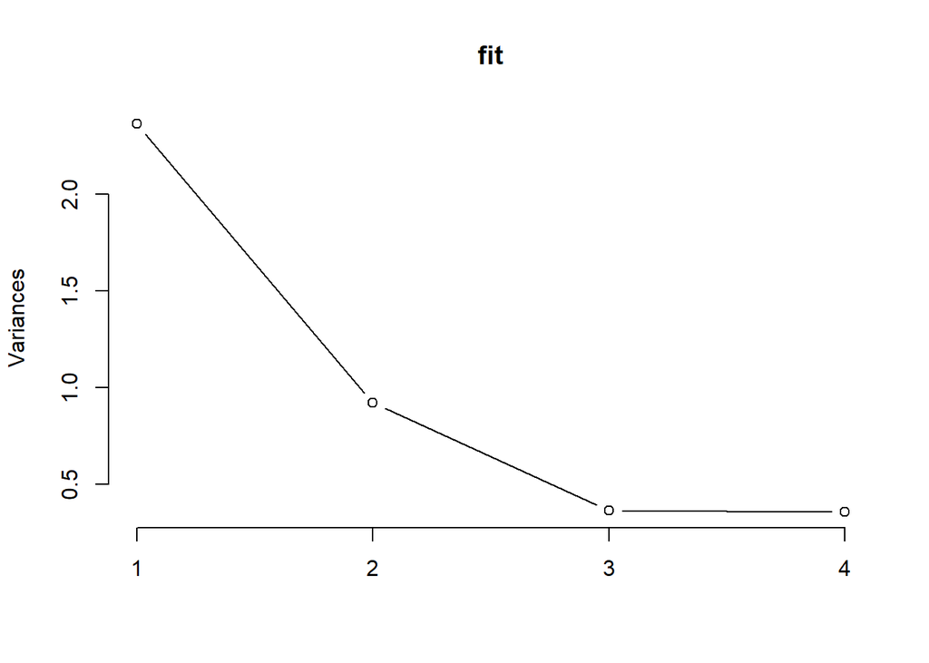

```r
plot(fit, type="l")
```

Scatterplot PC1 dan PC2

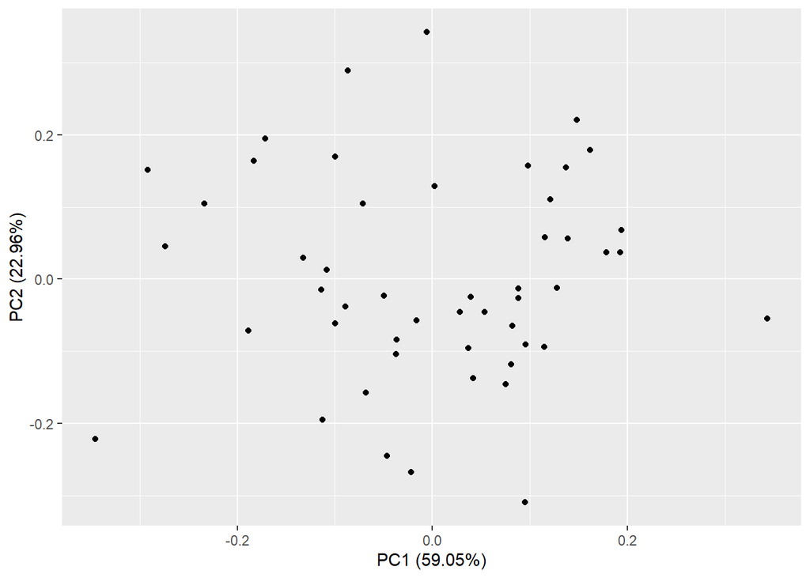

```r
autoplot(fit)
```

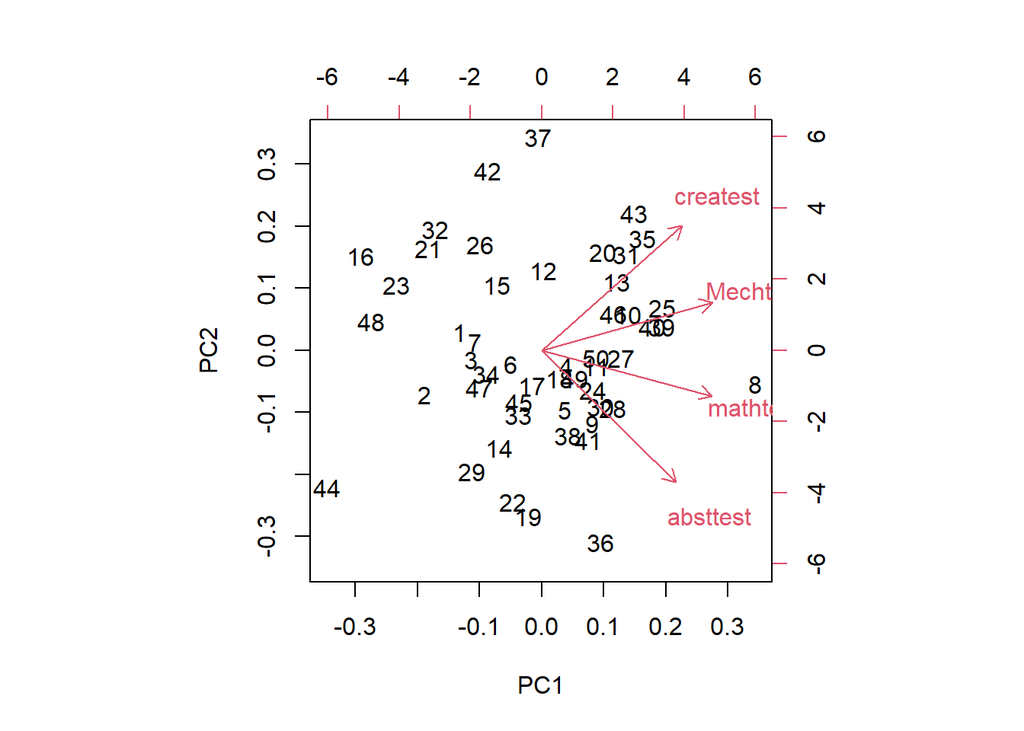

```r
biplot(fit)
```